# Using plot themes

Carmen Navarro

2020-05-27

```r
library(elsasserlib)
library(ggplot2)
library(scales)
```

## Summary

This is a brief documentation on how to use the plot themes included in the package. The idea is that this can help us keep a consistent *look and feel* when getting plots ready for publication. The most relevant need that triggered this was that we need pretty huge font sizes for the print panel version of the plots.

## Example

So as an example let’s take the usual `iris` dataset and plot it normally using ggplot:

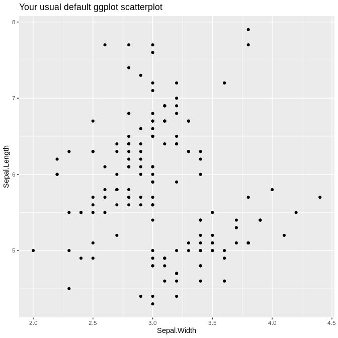

```r
normal.plot <- ggplot(iris, aes(x=Sepal.Width, y=Sepal.Length)) +
  geom_point() +
  ggtitle("Your usual default ggplot scatterplot")

normal.plot
```

You can modify the default behavior in your plot by adding one of the available themes there are.

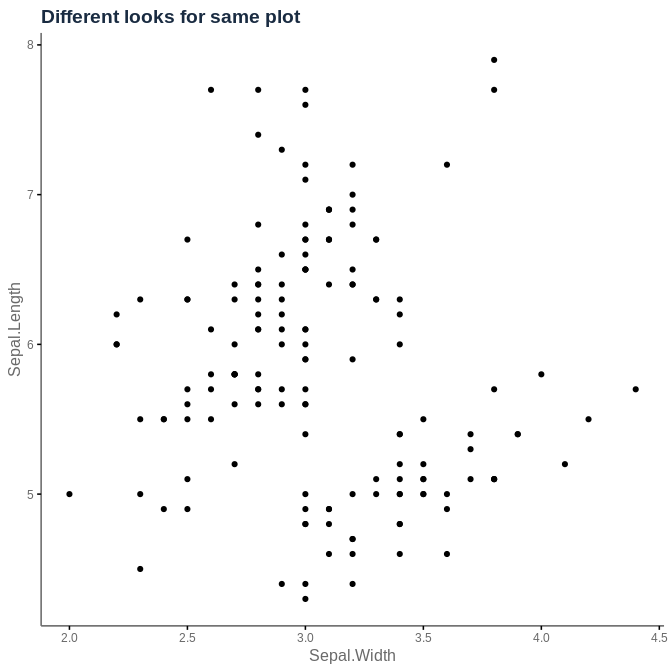

```r
normal.plot +
  ggtitle("Different looks for same plot") +
  theme_elsasserlab_screen()
```

Just some tweaking to the looks of the plot, because I like more minimalistic plots. If you want to use the `print` version, you just need to call `theme_elsasserlab_print()` after:

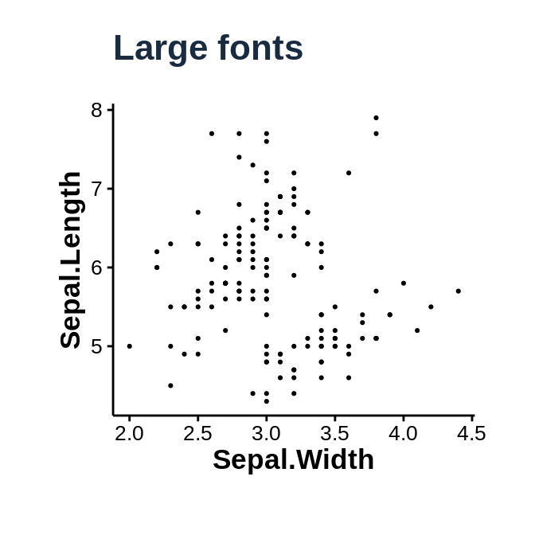

```r
normal.plot +
  ggtitle("Large fonts") +
  theme_elsasserlab_print()
```

## Customizing base themes

You can use the parameter `base_size` to tune the size of things in both screen and print plots.

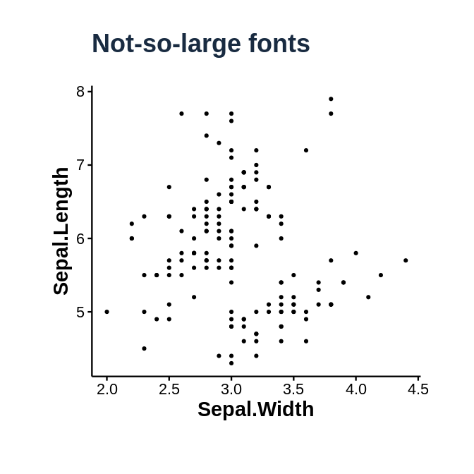

```r
# Same plot with slightly less huge fonts
normal.plot +
  ggtitle("Not-so-large fonts") +
  theme_elsasserlab_print(base_size=18)
```

In general, it’s pretty simple and works as any `ggplot2` operation. You can still override specifics if you need. Say that you want to rotate axis labels because you have long text there.

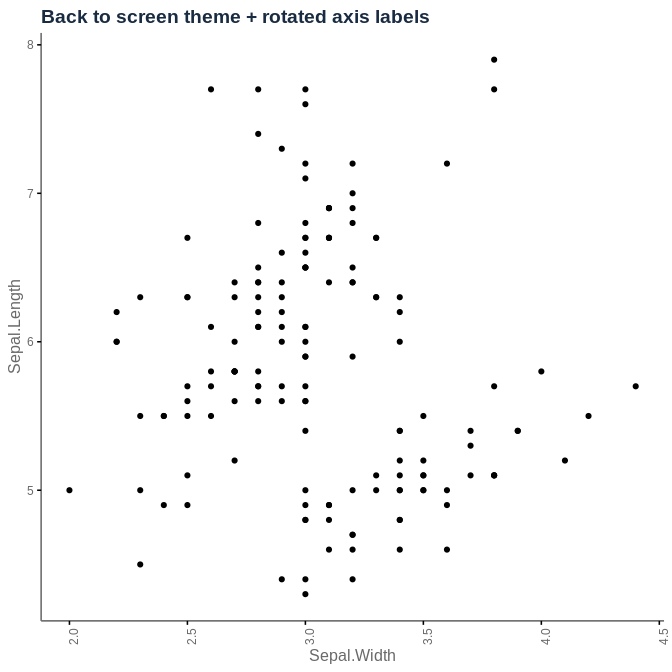

```r
normal.plot +
  ggtitle("Back to screen theme + rotated axis labels") +
  theme_elsasserlab_screen() +
  theme(axis.text.x = element_text(angle=90, hjust=1))
```

## Custom palette

This is something I did for myself because I did not quite like the colorsets for qualitative datasets I found. So I manually picked a few that I think play nice together and can be fairly distinguishable from each other.

`palette_categorical(n)` will give you a list of up to 12 colors for categorical data. If you ask for more than n though, it will provide something very similar to default ggplot hue scale.

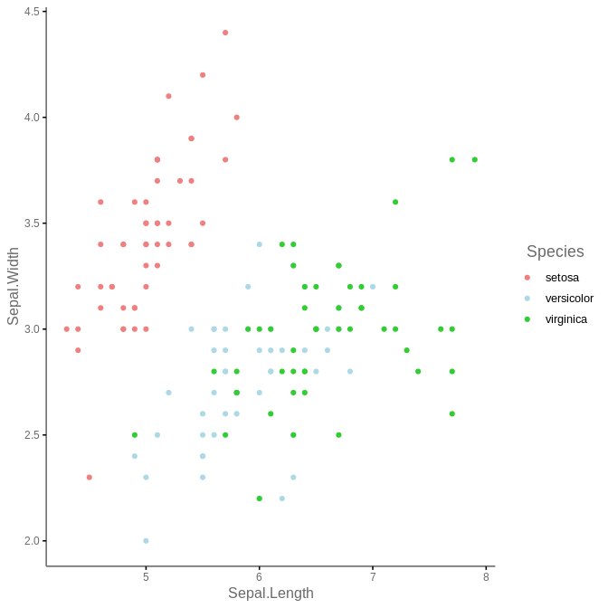

```r
categorical.plot <- ggplot(iris, aes(x=Sepal.Length, y=Sepal.Width, color=Species)) +
  geom_point() +
  theme_elsasserlab_screen() +
  scale_color_manual(values=palette_categorical(3))

categorical.plot
```

These are the colors included:

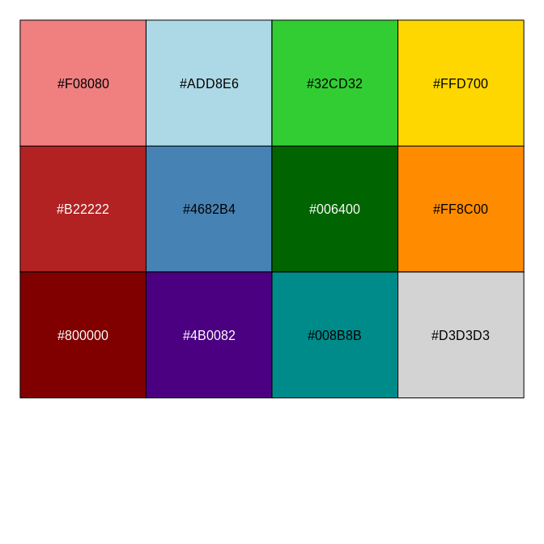

```r
show_col(palette_categorical(12))
```